# IODS course project

The bi-plot indicates that maternal mortality and adolescent birth rate are positively correlated with each other, and negatively correlated to GNI, expected years of schooling, life expectancy at birth, and to proportion of females with at least secondary education (which are all positively correlated with each other). These six variables all load mainly to component 1. Percetange of female representatives in parliament is positively correlated with the ratio of females to males in the labour force. These two variables mainly load to component 2.

Thus, the first component could be interpreted as something like “standards of living” and the second component as “gender equality”. Finally, let’s investigate how different countries are distributed among these two components.

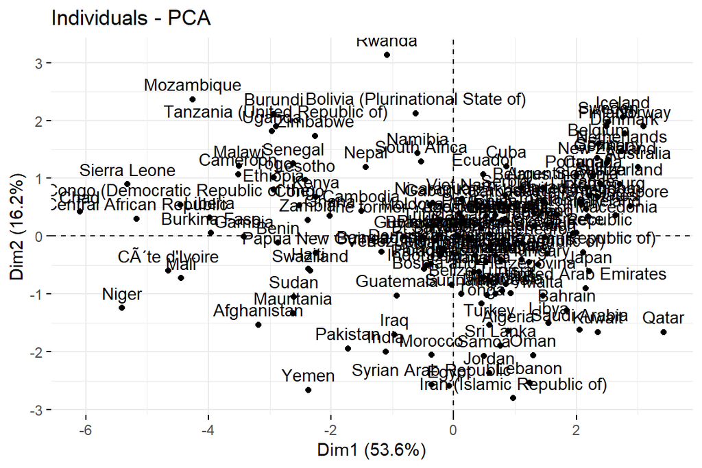

```r
fviz_pca_ind(res.PCA2, labelsize = 0.6, col.ind = "black")
```

The plot is quite messy, since we have over 100 countries visualized simultaneously. However, the fourfold table gives us a rough pattern, how the principal components could be used to classify different countries. On the lower left corner we see countires with relatively lower standards of living and worse gender equality, and on the upper left corner we see countries with lower standards of living and higher gender equality. On the right side we can infer the same pattern, but with countries with relatively higher standards of living.

Let’s make one more plot to get a bit more interpretable picture of the countries. To do this, we’ll make a plot, where we include only 50 countries with the biggest contribution to the component solution.

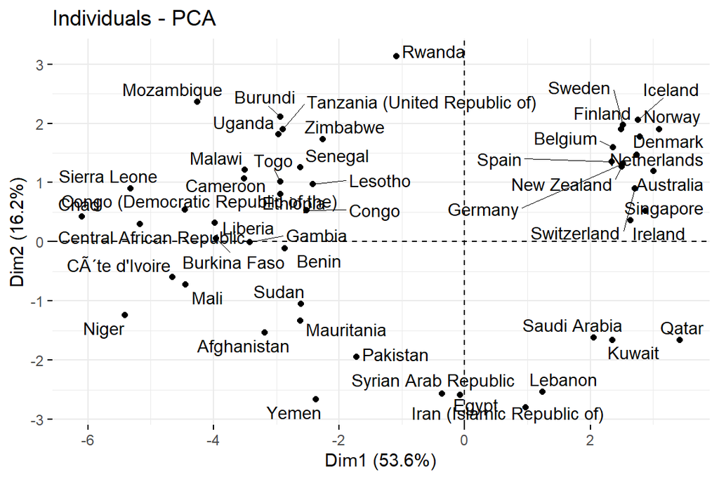

```r
fviz_pca_ind(res.PCA2, labelsize = 0.6, col.ind = "black", select.ind = list( contrib = 50), repel = TRUE)
```

Now that we can actually read the labels, we can say that the interpretation that we gave to our components, is not complete nonsense. It seems intuitively compelling, that many of the Western Europe (and especially Nordic) countries are located in the upper right corner with relatively high standard of living and high gender equality. On the lower right corner we can see countries such Saudi Arabia, Kuwait, and Qatar, where standard of living is higher but gender equality is worse. The left side of the plot is also somewhat convincing, countries such as Rwanda score higher on the gender equality and countries like Afghanistan and Yemen lower. Obviously, we also see lot of “expections” where our interpretation of the components doesn’t really reflect the coordinates of the countries in the plot (e.g. Rwanda is probably not the most “gender equal” country out of all the 155 countries, but the high score on component 2 reflects mainly the exceptional number of females in the parliament). It is also noteworthy, that our two components only retain around 70 % of the variation from the orginal data set, and that our first component accounts a lot more varition than our second component.

### **Multiple Correspondence Analysis (MCA)**

[Vehkalahti and Everitt (2018)](https://www.crcpress.com/Multivariate-Analysis-for-the-Behavioral-Sciences-Second-Edition/Vehkalahti-Everitt/p/book/9780815385158), informally, define correspondence analysis (which MCA is extension of) as:

> “*Quintessentially, correspondence analysis is a technique for displaying multivariate (often bivariate) categorical data graphically, by deriving coordinates to represent the categories of both the row and the column variables, which may then be plotted to display the pattern of association between the variables graphically.*”

Next we will perform a MCA to “tea” data set taken from the FactoMineR package. First, let’s open the data and explore it a bit.

```r
library(FactoMineR)
data("tea")
data2 <- as.data.frame(tea)
str(data2)
```

```
## 'data.frame':    300 obs. of  36 variables:
##  $ breakfast       : Factor w/ 2 levels "breakfast","Not.breakfast": 1 1 2 2 1 2 1 2 1 1 ...
##  $ tea.time        : Factor w/ 2 levels "Not.tea time",..: 1 1 2 1 1 1 2 2 2 1 ...
##  $ evening         : Factor w/ 2 levels "evening","Not.evening": 2 2 1 2 1 2 2 1 2 1 ...
##  $ lunch           : Factor w/ 2 levels "lunch","Not.lunch": 2 2 2 2 2 2 2 2 2 2 ...
##  $ dinner          : Factor w/ 2 levels "dinner","Not.dinner": 2 2 1 1 2 1 2 2 2 2 ...
##  $ always          : Factor w/ 2 levels "always","Not.always": 2 2 2 2 1 2 2 2 2 2 ...
##  $ home            : Factor w/ 2 levels "home","Not.home": 1 1 1 1 1 1 1 1 1 1 ...
##  $ work            : Factor w/ 2 levels "Not.work","work": 1 1 2 1 1 1 1 1 1 1 ...
##  $ tearoom         : Factor w/ 2 levels "Not.tearoom",..: 1 1 1 1 1 1 1 1 1 2 ...
##  $ friends         : Factor w/ 2 levels "friends","Not.friends": 2 2 1 2 2 2 1 2 2 2 ...
##  $ resto           : Factor w/ 2 levels "Not.resto","resto": 1 1 2 1 1 1 1 1 1 1 ...
##  $ pub             : Factor w/ 2 levels "Not.pub","pub": 1 1 1 1 1 1 1 1 1 1 ...
##  $ Tea             : Factor w/ 3 levels "black","Earl Grey",..: 1 1 2 2 2 2 2 1 2 1 ...
##  $ How             : Factor w/ 4 levels "alone","lemon",..: 1 3 1 1 1 1 1 3 3 1 ...
```

[output cut: 22 more lines]

```r
any(is.na.data.frame(data2))
```

```
## [1] FALSE
```

As we can see, we have 300 responders (rows) and 36 variables (columns). Everything except the participant age (“age”) are categorical variables. 7 of the categorical variables are non-binary and the rest are binary. There are no missing values.

According to FactoMineRs [webpage](http://factominer.free.fr/factomethods/multiple-correspondence-analysis.html) the data consist of: “*300 tea consumers [who] have answered a survey about their consumption of tea. The questions were about how they consume tea, how they think of tea and descriptive questions (sex, age, socio-professional category and sport practise). Except for the age, all the variables are categorical. For the age, the data set has two different variables: a continuous and a categorical one.*”

Our main interest here will be, how the socio-demographic factors are associated with peoples perception of tea. To investigate this, we will include the **following socio-demographic variables** to the analysis:

- **“sex”, “SPC”, age_Q"**.

And the following **variables concerning perception of tea**:

- **“escape.exoticism”, “spirituality”, “healthy”, “diuretic”, “friendliness”, “iron.absorption”, “feminine”, “sophisticated”, “slimming”, “exciting”, and “relaxing”, and “effect.on.health”**.

```r
MCA_data <- dplyr::select(data2, one_of(c("sex", "SPC", "age_Q", "escape.exoticism", "spirituality", "healthy", "diuretic", "friendliness", "iron.absorption", "feminine", "sophisticated", "slimming", "exciting", "relaxing", "effect.on.health")))
str(MCA_data)
```

```
## 'data.frame':    300 obs. of  15 variables:
##  $ sex             : Factor w/ 2 levels "F","M": 2 1 1 2 2 2 2 1 2 2 ...
##  $ SPC             : Factor w/ 7 levels "employee","middle",..: 2 2 4 6 1 6 5 2 5 5 ...
##  $ age_Q           : Factor w/ 5 levels "15-24","25-34",..: 3 4 4 1 4 1 3 3 3 3 ...
##  $ escape.exoticism: Factor w/ 2 levels "escape-exoticism",..: 2 1 2 1 1 2 2 2 2 2 ...
##  $ spirituality    : Factor w/ 2 levels "Not.spirituality",..: 1 1 1 2 2 1 1 1 1 1 ...
##  $ healthy         : Factor w/ 2 levels "healthy","Not.healthy": 1 1 1 1 2 1 1 1 2 1 ...
##  $ diuretic        : Factor w/ 2 levels "diuretic","Not.diuretic": 2 1 1 2 1 2 2 2 2 1 ...
##  $ friendliness    : Factor w/ 2 levels "friendliness",..: 2 2 1 2 1 2 2 1 2 1 ...
##  $ iron.absorption : Factor w/ 2 levels "iron absorption",..: 2 2 2 2 2 2 2 2 2 2 ...
##  $ feminine        : Factor w/ 2 levels "feminine","Not.feminine": 2 2 2 2 2 2 2 1 2 2 ...
##  $ sophisticated   : Factor w/ 2 levels "Not.sophisticated",..: 1 1 1 2 1 1 1 2 2 1 ...
##  $ slimming        : Factor w/ 2 levels "No.slimming",..: 1 1 1 1 1 1 1 1 1 1 ...
##  $ exciting        : Factor w/ 2 levels "exciting","No.exciting": 2 1 2 2 2 2 2 2 2 2 ...
##  $ relaxing        : Factor w/ 2 levels "No.relaxing",..: 1 1 2 2 2 2 2 2 2 2 ...
##  $ effect.on.health: Factor w/ 2 levels "effect on health",..: 2 2 2 2 2 2 2 2 2 2 ...
```

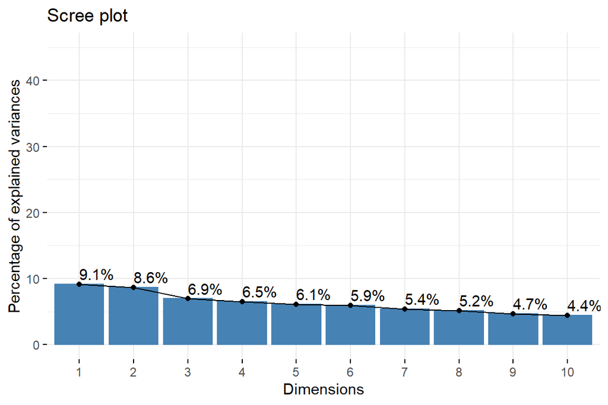

```r
res.MCA <- MCA(MCA_data, graph = FALSE)
fviz_screeplot(res.MCA, addlabels = TRUE, ylim = c( 0, 45))
```

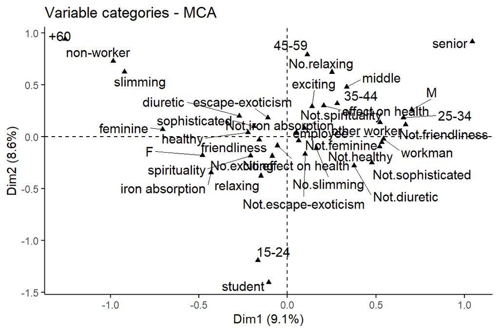

```r
var3 <- get_mca_var(res.MCA)
fviz_mca_var(res.MCA, repel = TRUE, ggtheme = theme_classic(), col.var = "black")
```

From the scree-plot we can see that two dimensional representation of data is not accounting for much of the variation observed in the original table (only 17.7 %). As a result, most of the variables are concentrated near the center of the bi-plot. We can visualize this by coloring each variable according to it’s cos2 value (which gives us indication how well each category is represented by the two dimensions).

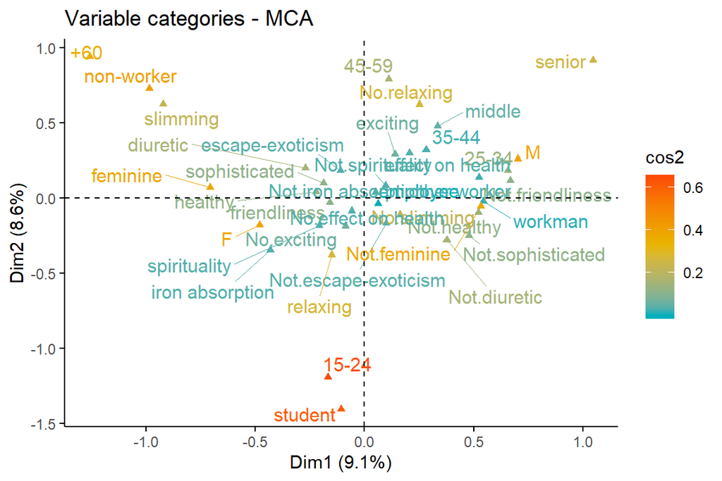

```r
fviz_mca_var(res.MCA, col.var = "cos2", gradient.cols = c("#00AFBB", "#E7B800", "#FC4E07"), repel = TRUE, ggtheme = theme_classic())
```

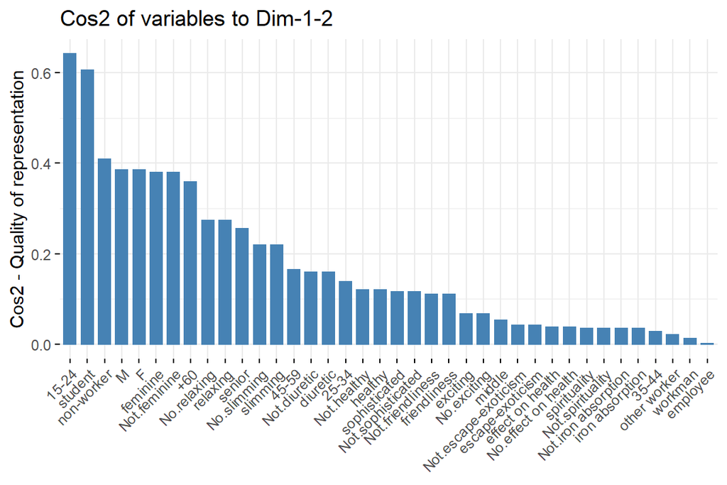

```r
fviz_cos2(res.MCA, choice = "var", axes = 1: 2)
```

It seems, that our two dimensions does not represent particularly well “escape-exoticism”, “iron absoption”, “spirituality”, or “effect on health”. Because we are primarily practicing how to use the method, we don’t have strong reasons to keep any particular variable in the model. Thus, let’s get rid of the the aforementioned variables and run the MCA again.

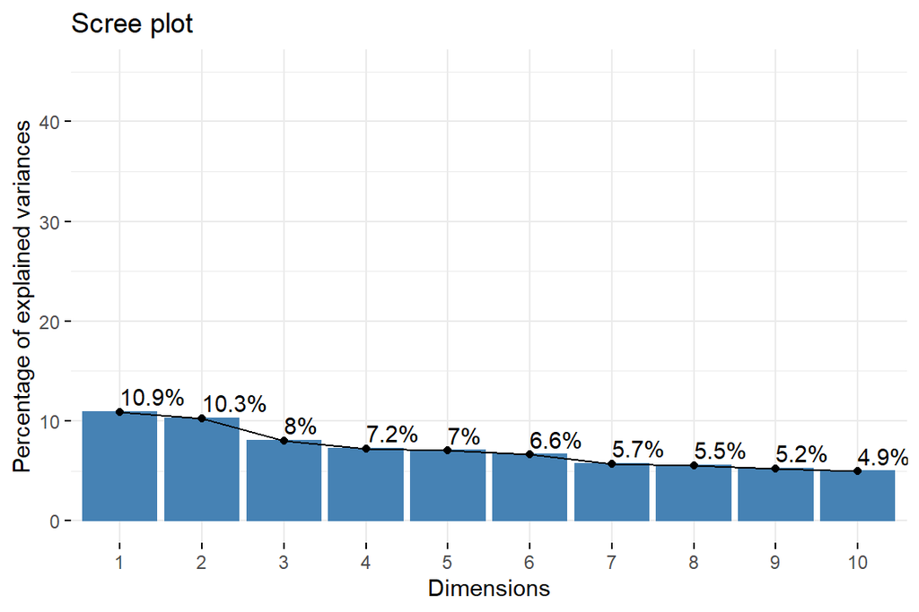

```r
MCA_data2 <- dplyr::select(MCA_data, one_of(c("sex", "SPC", "age_Q", "healthy", "diuretic", "friendliness", "feminine", "sophisticated", "slimming", "exciting", "relaxing")))
res2.MCA <- MCA(MCA_data2, graph = FALSE)
fviz_screeplot(res2.MCA, addlabels = TRUE, ylim = c( 0, 45))
```

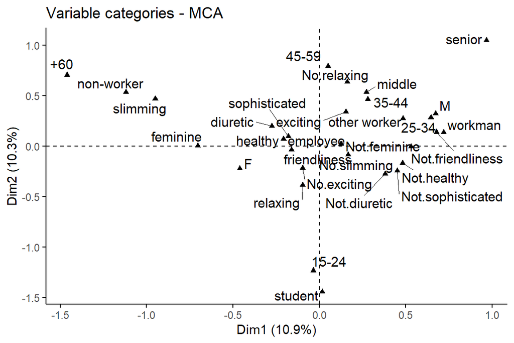

```r
fviz_mca_var(res2.MCA, repel = TRUE, ggtheme = theme_classic(), col.var = "black")
```

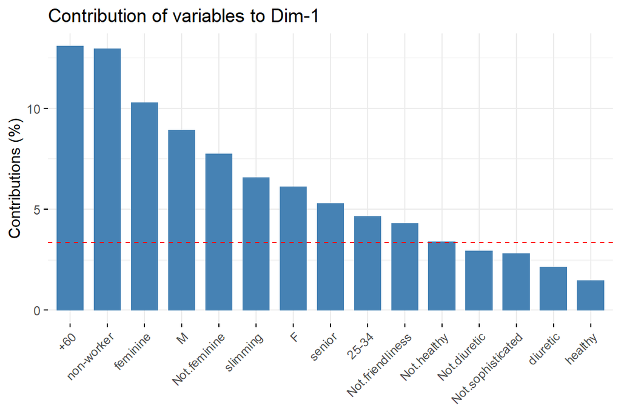

```r
fviz_contrib(res2.MCA, choice = "var", axes = 1, top = 15)
```

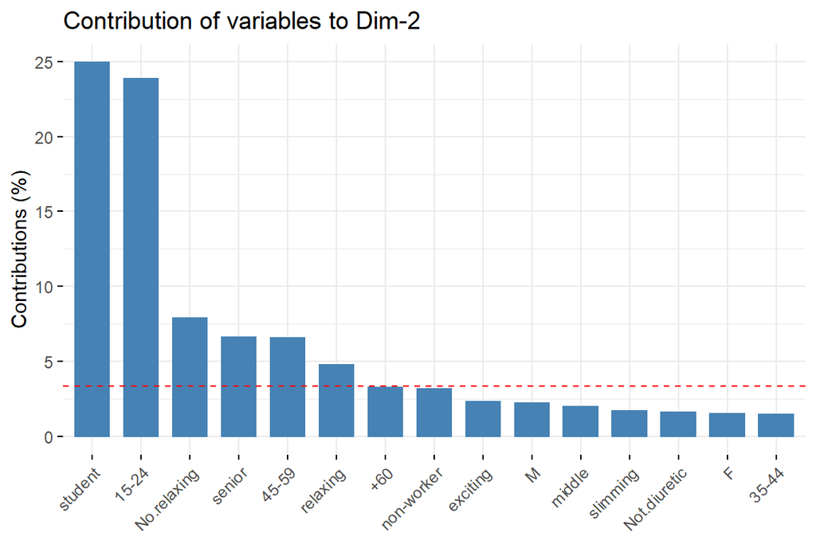

```r
fviz_contrib(res2.MCA, choice = "var", axes = 2, top = 15)
```

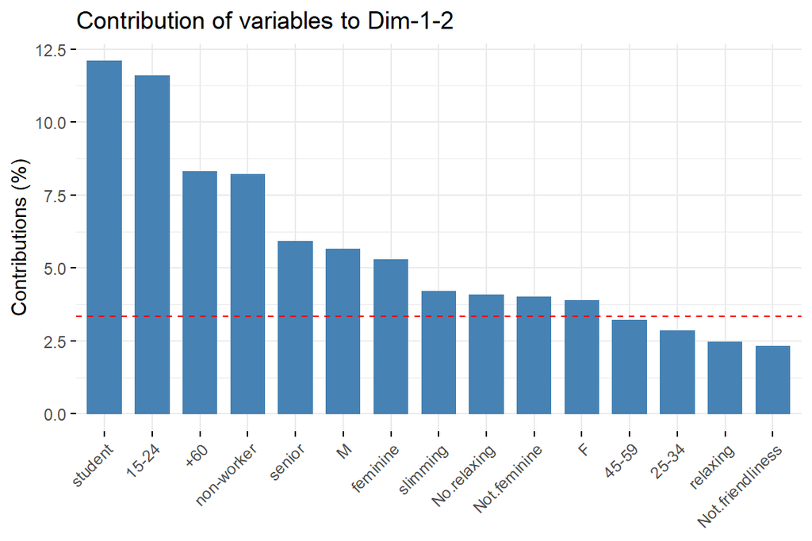

```r
fviz_contrib(res2.MCA, choice = "var", axes = 1: 2, top = 15)
```

It seems that age and work position (SPC) are especially influential variables, while most of the tea perception categories (with exception of “feminine”/not.feminine) are less influential.

Let’s do one more bi-plot, where the contribution of each category is also visible.

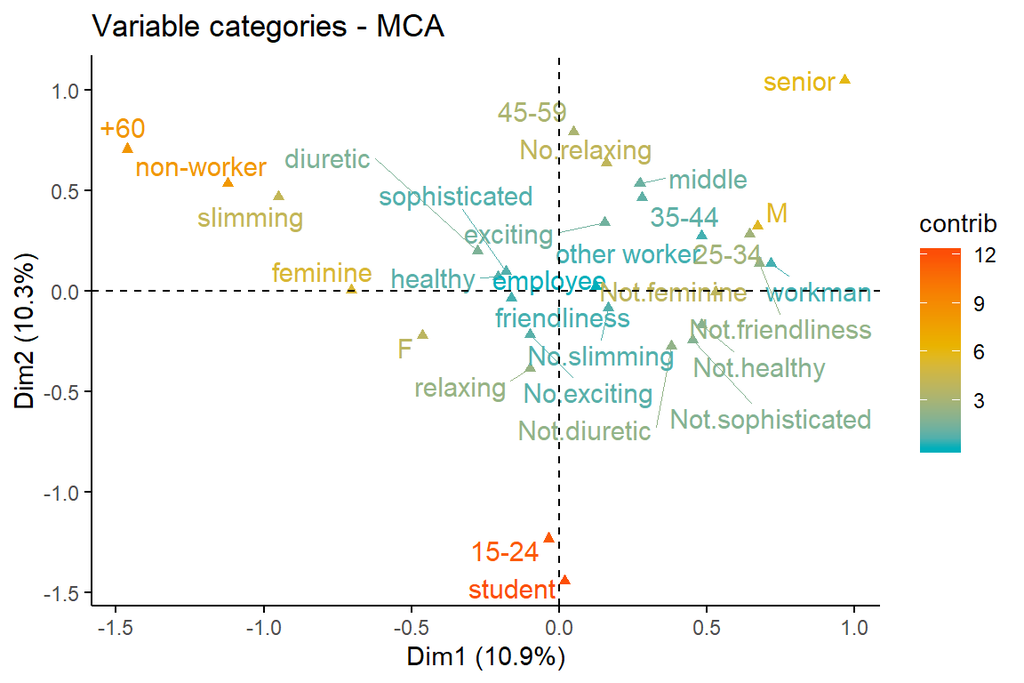

```r
fviz_mca_var(res2.MCA, col.var = "contrib", gradient.cols = c("#00AFBB", "#E7B800", "#FC4E07"), repel = TRUE, ggtheme = theme_classic())
```

Here the proximity of the categories to each other reflects how similar these column points are when their profiles are compared down the rows (which represent the respondents in this case). Similar profiles are grouped together and negatively correlated variables are positioned on opposite sides of the plot. For example, category “student” and age group “15-24” are clearly associated with each other and they contribute strongly to the neagative pole of the dimension 2. Likewise, age group “+60” and “non-worker” are associated with each other and contribute most to the negative pole of dimension 1.

To get back to our research question, we can preliminary say that there might be an association between being non-worker and/or +60 and perceiving tea as slimming. Also, there might be an association between being senior (job position) and/or “45-59” and perceiving tea as not relaxing. Being male might to be associated with perceiving tea as not feminine, not relaxing, and not friendly; and beign female with feminine, friendly, and relaxing. Obviously caution should be applied here, since we are only eyeballing the bi-plot and our dimension are not reataining most of the inertia in the first place.

# **RStudio Exercise 6: Analysis of Longitudinal Data**

First we will open all the required data files. (For detailed documentation how the data was created see: https://github.com/ohwhalme/IODS-project/blob/master/data/meet_and_repeat.R)

```r
BPRS <- read.csv("C:/Users/OHW/Desktop/R/IODS-project/data/BPRS.csv")
BPRSL <- read.csv("C:/Users/OHW/Desktop/R/IODS-project/data/BPRSL.csv")
RATS <- read.csv("C:/Users/OHW/Desktop/R/IODS-project/data/RATS.csv")
RATSL <- read.csv("C:/Users/OHW/Desktop/R/IODS-project/data/RATSL.csv")
BPRS$treatment <- factor(BPRS$treatment)
BPRS$subject <- factor(BPRS$subject)
BPRSL$treatment <- factor(BPRSL$treatment)
BPRSL$subject <- factor(BPRSL$subject)
RATS$ID <- factor(RATS$ID)
RATS$Group <- factor(RATS$Group)
RATSL$ID <- factor(RATSL$ID)
RATSL$Group <- factor(RATSL$Group)
```

Then we will proceed to “Implement the analyses of Chapter 8 of MABS using the RATS data”.

#### **Comparing long and wide form of RATS**:

```r
glimpse(RATS)
```

```
## Observations: 16
## Variables: 14
## $ X     <int> 1, 2, 3, 4, 5, 6, 7, 8, 9, 10, 11, 12, 13, 14, 15, 16
## $ ID    <fct> 1, 2, 3, 4, 5, 6, 7, 8, 9, 10, 11, 12, 13, 14, 15, 16
## $ Group <fct> 1, 1, 1, 1, 1, 1, 1, 1, 2, 2, 2, 2, 3, 3, 3, 3
## $ WD1   <int> 240, 225, 245, 260, 255, 260, 275, 245, 410, 405, 445, 5...
## $ WD8   <int> 250, 230, 250, 255, 260, 265, 275, 255, 415, 420, 445, 5...
## $ WD15  <int> 255, 230, 250, 255, 255, 270, 260, 260, 425, 430, 450, 5...
## $ WD22  <int> 260, 232, 255, 265, 270, 275, 270, 268, 428, 440, 452, 5...
## $ WD29  <int> 262, 240, 262, 265, 270, 275, 273, 270, 438, 448, 455, 5...
## $ WD36  <int> 258, 240, 265, 268, 273, 277, 274, 265, 443, 460, 455, 5...
## $ WD43  <int> 266, 243, 267, 270, 274, 278, 276, 265, 442, 458, 451, 5...
## $ WD44  <int> 266, 244, 267, 272, 273, 278, 271, 267, 446, 464, 450, 5...
## $ WD50  <int> 265, 238, 264, 274, 276, 284, 282, 273, 456, 475, 462, 6...
## $ WD57  <int> 272, 247, 268, 273, 278, 279, 281, 274, 468, 484, 466, 6...
## $ WD64  <int> 278, 245, 269, 275, 280, 281, 284, 278, 478, 496, 472, 6...
```

```r
head(RATS)
```

```
##   X ID Group WD1 WD8 WD15 WD22 WD29 WD36 WD43 WD44 WD50 WD57 WD64
## 1 1  1     1 240 250  255  260  262  258  266  266  265  272  278
## 2 2  2     1 225 230  230  232  240  240  243  244  238  247  245
## 3 3  3     1 245 250  250  255  262  265  267  267  264  268  269
## 4 4  4     1 260 255  255  265  265  268  270  272  274  273  275
## 5 5  5     1 255 260  255  270  270  273  274  273  276  278  280
## 6 6  6     1 260 265  270  275  275  277  278  278  284  279  281
```

```r
tail(RATS)
```

```
##     X ID Group WD1 WD8 WD15 WD22 WD29 WD36 WD43 WD44 WD50 WD57 WD64
## 11 11 11     2 445 445  450  452  455  455  451  450  462  466  472
## 12 12 12     2 555 560  565  580  590  597  595  595  612  618  628
## 13 13 13     3 470 465  475  485  487  493  493  504  507  518  525
## 14 14 14     3 535 525  530  533  535  540  525  530  543  544  559
## 15 15 15     3 520 525  530  540  543  546  538  544  553  555  548
## 16 16 16     3 510 510  520  515  530  538  535  542  550  553  569
```

```r
glimpse(RATSL)
```

```
## Observations: 176
## Variables: 6
## $ X      <int> 1, 2, 3, 4, 5, 6, 7, 8, 9, 10, 11, 12, 13, 14, 15, 16, ...
## $ ID     <fct> 1, 2, 3, 4, 5, 6, 7, 8, 9, 10, 11, 12, 13, 14, 15, 16, ...
## $ Group  <fct> 1, 1, 1, 1, 1, 1, 1, 1, 2, 2, 2, 2, 3, 3, 3, 3, 1, 1, 1...
## $ WD     <fct> WD1, WD1, WD1, WD1, WD1, WD1, WD1, WD1, WD1, WD1, WD1, ...
## $ Weight <int> 240, 225, 245, 260, 255, 260, 275, 245, 410, 405, 445, ...
## $ Time   <int> 1, 1, 1, 1, 1, 1, 1, 1, 1, 1, 1, 1, 1, 1, 1, 1, 8, 8, 8...
```

```r
head(RATSL)
```

```
##   X ID Group  WD Weight Time
## 1 1  1     1 WD1    240    1
## 2 2  2     1 WD1    225    1
## 3 3  3     1 WD1    245    1
## 4 4  4     1 WD1    260    1
## 5 5  5     1 WD1    255    1
## 6 6  6     1 WD1    260    1
```

```r
tail(RATSL)
```

```
##       X ID Group   WD Weight Time
## 171 171 11     2 WD64    472   64
## 172 172 12     2 WD64    628   64
## 173 173 13     3 WD64    525   64
## 174 174 14     3 WD64    559   64
## 175 175 15     3 WD64    548   64
## 176 176 16     3 WD64    569   64
```

The wide form consist of 16 observations and 13 variables and the long form of 176 observations and 5 variables. As explained earlier (see above the link for how the data was created), in the data set we have 16 rats who have been assigned to 3 different experimental groups (diet) and their weight have been followed for 9 weeks. Wide form represents each individual on single row and the measurement points (WD1 to WD64) as separate variables. In the long form each participant is stacked on top of each other 11 times (reflecting the number of measurement points) and each days outcome (grams) are recoded into single variable.

#### **Presenting RATS visually and standardizing the data**:

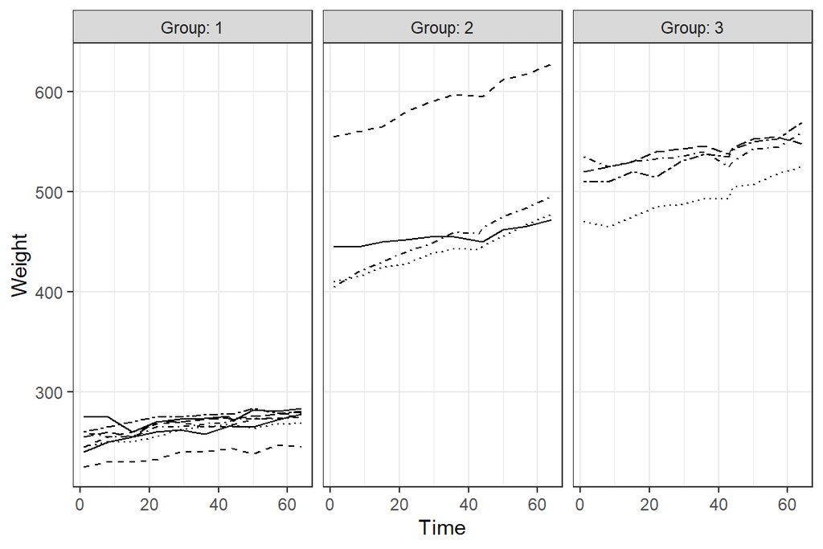

```r
p1 <- ggplot(RATSL, aes(x = Time, y = Weight, linetype = ID))
p2 <- p1 + geom_line() + scale_linetype_manual(values = rep(1:10, times=4))
p3 <- p2 + facet_grid(. ~ Group, labeller = label_both)
p4 <- p3 + theme_bw() + theme(legend.position = "none")
p5 <- p4 + theme(panel.grid.minor.y = element_blank())
p6 <- p5 + scale_y_continuous(limits = c(min(RATSL$Weight), max(RATSL$Weight)))
p6
```

Above we have plotted the 8 rats from group 1, 4 rats from group 2, and 4 rats from group 3 across the 9 week time period. On y-axis we have assigned rats weight on grams. We can infer that the group 1 is considerably lighter from base line to end of the trial than the groups 2 and 3 (i.e. rats were smaller to begin with in group 1). There seems to exist slight upwards trend in all of the groups indicating that the rats are gaining weight as the trial goes on. There does not seem to be great differences in the variability of individual rats weight across time, although the intercepts do differ quite much (across groups, but also within groups we can see at least one individual whos starting weight is considerably higher/lower that others in the group).

Next, we will standardize the outcome values (grouped by time: Weight - mean(Weight))/sd(Weight)) and create the same plot.

```r
RATSL <- RATSL %>%
  group_by(Time) %>%
  mutate( stdWeight = (Weight - mean(Weight))/sd(Weight) ) %>%
  ungroup()
glimpse(RATSL)
```

```
## Observations: 176
## Variables: 7
## $ X         <int> 1, 2, 3, 4, 5, 6, 7, 8, 9, 10, 11, 12, 13, 14, 15, 1...
## $ ID        <fct> 1, 2, 3, 4, 5, 6, 7, 8, 9, 10, 11, 12, 13, 14, 15, 1...
## $ Group     <fct> 1, 1, 1, 1, 1, 1, 1, 1, 2, 2, 2, 2, 3, 3, 3, 3, 1, 1...
## $ WD        <fct> WD1, WD1, WD1, WD1, WD1, WD1, WD1, WD1, WD1, WD1, WD...
## $ Weight    <int> 240, 225, 245, 260, 255, 260, 275, 245, 410, 405, 44...
## $ Time      <int> 1, 1, 1, 1, 1, 1, 1, 1, 1, 1, 1, 1, 1, 1, 1, 1, 8, 8...
## $ stdWeight <dbl> -1.0011429, -1.1203857, -0.9613953, -0.8421525, -0.8...
```

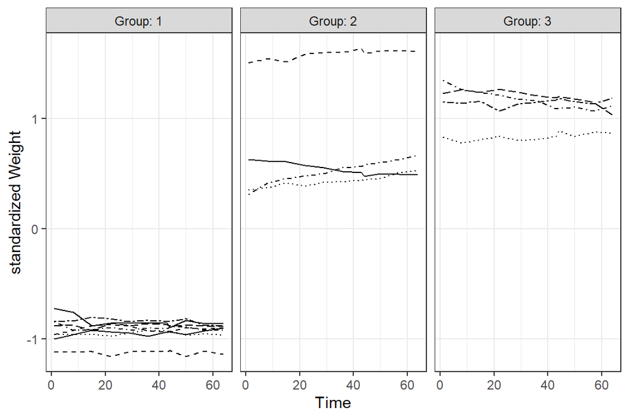

```r
p1 <- ggplot(RATSL, aes(x = Time, y = stdWeight, linetype = ID))
p2 <- p1 + geom_line() + scale_linetype_manual(values = rep(1:10, times=4))
p3 <- p2 + facet_grid(. ~ Group, labeller = label_both)
p4 <- p3 + theme_bw() + theme(legend.position = "none")
p5 <- p4 + theme(panel.grid.minor.y = element_blank())
p6 <- p5 + scale_y_continuous(name = "standardized Weight")
p6
```

Now “Weight” has mean of 0 and standard deviation of 1 on each measurement point (time). This highlights the fact that different individuals have different intercepts on “Weight”. Because the standardation was grouped by time, the trends look somewhat different when compared to the first plot (standardization was mainly done to better show the “tracking” phenomenon, not so much to interpret the results).

Next we will plot mean response profiles for the 3 dietary groups.

```r
n <- RATSL$Time %>% unique() %>% length()

RATSS <- RATSL %>%
  group_by(Group, Time) %>%
  summarise(mean = mean(Weight), se = sd(Weight)/sqrt(n) ) %>%
  ungroup()
glimpse(RATSS)
```

```
## Observations: 33
## Variables: 4
## $ Group <fct> 1, 1, 1, 1, 1, 1, 1, 1, 1, 1, 1, 2, 2, 2, 2, 2, 2, 2, 2,...
## $ Time  <int> 1, 8, 15, 22, 29, 36, 43, 44, 50, 57, 64, 1, 8, 15, 22, ...
## $ mean  <dbl> 250.625, 255.000, 254.375, 261.875, 264.625, 265.000, 26...
## $ se    <dbl> 4.589478, 3.947710, 3.460116, 4.100800, 3.333956, 3.5529...
```

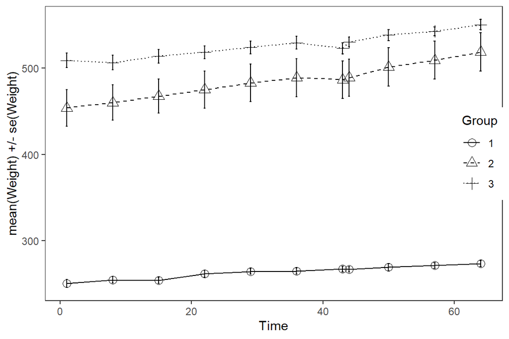

```r
p1 <- ggplot(RATSS, aes(x = Time, y = mean, linetype = Group, shape = Group))
p2 <- p1 + geom_line() + scale_linetype_manual(values = c(1:3))
p3 <- p2 + geom_point(size=3) + scale_shape_manual(values = c(1:3))
p4 <- p3 + geom_errorbar(aes(ymin=mean-se, ymax=mean+se, linetype="1"), width=0.3)
p5 <- p4 + theme_bw() + theme(panel.grid.major = element_blank(), panel.grid.minor = element_blank())
p6 <- p5 + theme(legend.position = c(0.95,0.5))
p7 <- p6 + scale_y_continuous(name = "mean(Weight) +/- se(Weight)")
p7
```

On x-axis we have plotted “Time” (i.e. measurement points) and on y-axis we have weight in grams. Different lines represent different experimental groups. Each score indicate particular groups mean weight in particular measurement point (standard errors are included as error bars). We can infer from the plot that, when mean response scores are scrutinized, different groups have different intercepts. Baseline for group 1 is considerably lower than baselines for groups 2 or 3. Similarly, baseline for group 2 is slightly lower when compared to group 3. Error bars indicate that variation is greatest in group 2 and lowest in group 1 (which most likely reflects the difference in sample size between the group 1 and the other groups). The slopes indicate roughly similar trend in all of the groups, so it’s difficult to infer whether the experimental manipulation is having any effect.

Next, to investigate presence of possible outliers, we will create box plots for the same set-up.

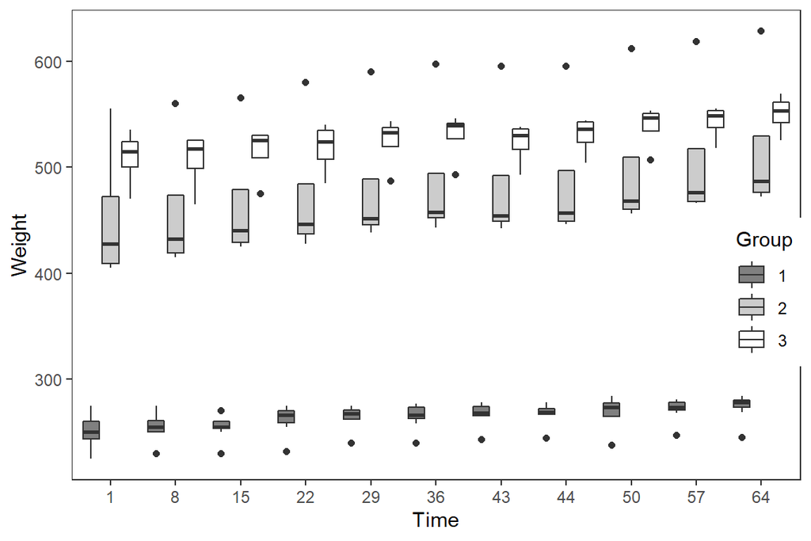

```r
p1 <- ggplot(RATSL, aes(x = factor(Time), y = Weight, fill = Group))
p2 <- p1 + geom_boxplot(position = position_dodge(width = 0.9))
p3 <- p2 + theme_bw() + theme(panel.grid.major = element_blank(), panel.grid.minor = element_blank())
p4 <- p3 + theme(legend.position = c(0.95,0.4))
p5 <- p4 + scale_x_discrete(name = "Time")
p6 <- p5 + scale_fill_grey(start = 0.5, end = 1)
p6
```

It seems that we can spot multiple potential outliers. These most likely reflect the few deviating individuals within groups that were shown in the earlier plot where rats were individually plotted across time.

Since we are going to summarize the groups, we want to get rid of any outliers within groups. Next we will filter out the above seen outliers and show box plots of mean summary measures for the experimental groups (first with the outliers, then without the outliers).

```r
RATSL8S <- RATSL %>%
  filter(Time > 0) %>%
  group_by(Group, ID) %>%
  summarise(mean=mean(Weight) ) %>%
  ungroup()

glimpse(RATSL8S)
```

```
## Observations: 16
## Variables: 3
## $ Group <fct> 1, 1, 1, 1, 1, 1, 1, 1, 2, 2, 2, 2, 3, 3, 3, 3
## $ ID    <fct> 1, 2, 3, 4, 5, 6, 7, 8, 9, 10, 11, 12, 13, 14, 15, 16
## $ mean  <dbl> 261.0909, 237.6364, 260.1818, 266.5455, 269.4545, 274.72...
```

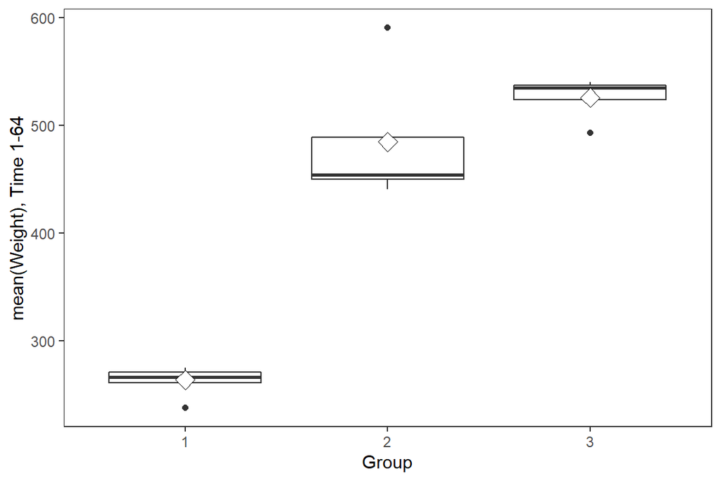

```r
p1 <- ggplot(RATSL8S, aes(x = Group, y = mean))
p2 <- p1 + geom_boxplot()
p3 <- p2 + theme_bw() + theme(panel.grid.major = element_blank(), panel.grid.minor = element_blank())
p4 <- p3 + stat_summary(fun.y = "mean", geom = "point", shape=23, size=4, fill = "white")
p5 <- p4 + scale_y_continuous(name = "mean(Weight), Time 1-64")
p5
```

```r
RATSL8S1 <- RATSL8S %>%
  filter(mean < 550)
RATSL8S1 <- RATSL8S %>%
  filter(mean > 240)
RATSL8SG3 <- subset(RATSL8S, Group==3, select=c(Group, ID, mean)) %>%
  filter(mean > 500)

RATSL8SG12 <- subset(RATSL8S1, Group==1:2, select=c(Group, ID, mean))
RATSL8S1 <- rbind(RATSL8SG12, RATSL8SG3)

glimpse(RATSL8S1)
```

```
## Observations: 9
## Variables: 3
## $ Group <fct> 1, 1, 1, 1, 2, 2, 3, 3, 3
## $ ID    <fct> 1, 4, 6, 8, 9, 11, 14, 15, 16
## $ mean  <dbl> 261.0909, 266.5455, 274.7273, 265.4545, 440.8182, 454.81...
```

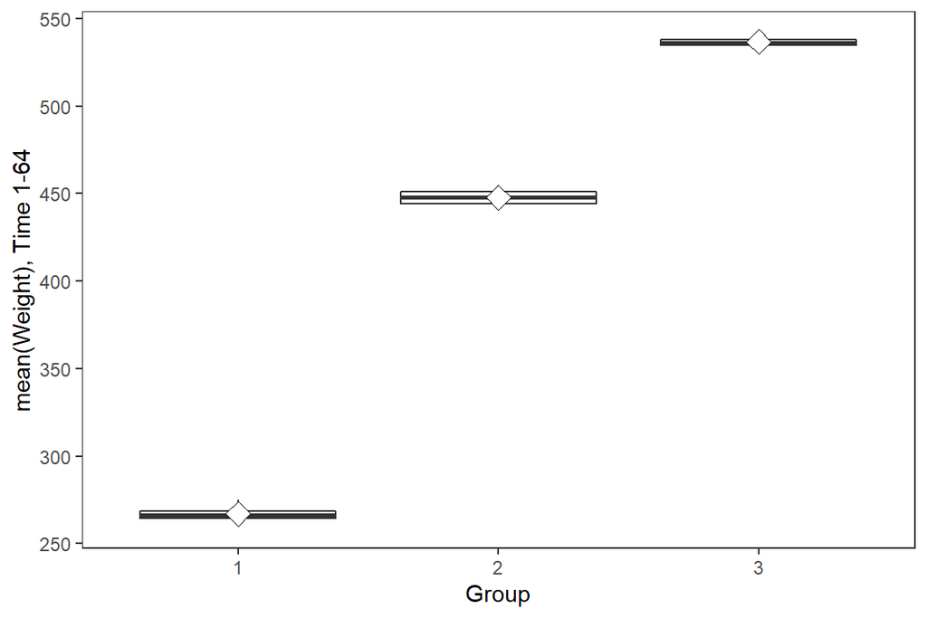

```r
p1 <- ggplot(RATSL8S1, aes(x = Group, y = mean))
p2 <- p1 + geom_boxplot()
p3 <- p2 + theme_bw() + theme(panel.grid.major = element_blank(), panel.grid.minor = element_blank())
p4 <- p3 + stat_summary(fun.y = "mean", geom = "point", shape=23, size=4, fill = "white")
p5 <- p4 + scale_y_continuous(name = "mean(Weight), Time 1-64")
p5
```

To be exact, we will also run a formal test (ANOVA) for the difference between the three experimental groups.

```r
fit1 <- lm(mean ~ Group, data = RATSL8S1)
summary(fit1)
```

```
##
## Call:
## lm(formula = mean ~ Group, data = RATSL8S1)
##
## Residuals:
##     Min      1Q  Median      3Q     Max
## -7.0000 -2.9394 -0.4848  3.4242  7.7727
##
## Coefficients:
##             Estimate Std. Error t value Pr(>|t|)
## (Intercept)  266.955      2.999   89.02 1.35e-10 ***
## Group2       180.864      5.194   34.82 3.74e-08 ***
## Group3       269.803      4.581   58.90 1.61e-09 ***
## ---
## Signif. codes:  0 '***' 0.001 '**' 0.01 '*' 0.05 '.' 0.1 ' ' 1
##
## Residual standard error: 5.997 on 6 degrees of freedom
## Multiple R-squared:  0.9984, Adjusted R-squared:  0.9978
## F-statistic:  1827 on 2 and 6 DF,  p-value: 4.408e-09
```

```r
anova(fit1)
```

```
## Analysis of Variance Table
##
## Response: mean
##           Df Sum Sq Mean Sq F value    Pr(>F)
## Group      2 131409   65704  1826.7 4.408e-09 ***
## Residuals  6    216      36
## ---
## Signif. codes:  0 '***' 0.001 '**' 0.01 '*' 0.05 '.' 0.1 ' ' 1
```

The test confirms what we inspected earlier from the plot, the group means significantly differ from each other (at least when contrasted to group 1).

Let’s do one more model were we include the baseline as a covariate to the model (to be precise, we will use first measurement point after the experiment has started as our baseline measure).

```r
baseline <- RATS$WD1
RATSL8S2 <- RATSL8S %>%
  mutate(baseline)

fit2 <- lm(mean ~ baseline + Group, data = RATSL8S2)
summary(fit2)
```

```
##
## Call:
## lm(formula = mean ~ baseline + Group, data = RATSL8S2)
##
## Residuals:
##     Min      1Q  Median      3Q     Max
## -21.732  -3.812   1.991   6.889  13.455
##
## Coefficients:
##             Estimate Std. Error t value Pr(>|t|)
## (Intercept) 30.14886   19.88779   1.516   0.1554
## baseline     0.93194    0.07793  11.959 5.02e-08 ***
## Group2      31.68866   17.11189   1.852   0.0888 .
## Group3      21.52296   21.13931   1.018   0.3287
## ---
## Signif. codes:  0 '***' 0.001 '**' 0.01 '*' 0.05 '.' 0.1 ' ' 1
##
## Residual standard error: 10.62 on 12 degrees of freedom
## Multiple R-squared:  0.9947, Adjusted R-squared:  0.9933
## F-statistic: 747.8 on 3 and 12 DF,  p-value: 6.636e-14
```

```r
anova(fit2)
```

```
## Analysis of Variance Table
##
## Response: mean
##           Df Sum Sq Mean Sq   F value    Pr(>F)
## baseline   1 252125  252125 2237.0655 5.217e-15 ***
## Group      2    726     363    3.2219   0.07586 .
## Residuals 12   1352     113
## ---
## Signif. codes:  0 '***' 0.001 '**' 0.01 '*' 0.05 '.' 0.1 ' ' 1
```

Next we will “Implement the analyses of Chapter 9 of MABS using the BPRS data.”

#### **Comparing long and wide form of BPRS**:

For variable description see https://github.com/ohwhalme/IODS-project/blob/master/data/meet_and_repeat.R)

```r
glimpse(BPRS)
```

```
## Observations: 40
## Variables: 12
## $ X         <int> 1, 2, 3, 4, 5, 6, 7, 8, 9, 10, 11, 12, 13, 14, 15, 1...
## $ treatment <fct> 1, 1, 1, 1, 1, 1, 1, 1, 1, 1, 1, 1, 1, 1, 1, 1, 1, 1...
## $ subject   <fct> 1, 2, 3, 4, 5, 6, 7, 8, 9, 10, 11, 12, 13, 14, 15, 1...
## $ week0     <int> 42, 58, 54, 55, 72, 48, 71, 30, 41, 57, 30, 55, 36, ...
## $ week1     <int> 36, 68, 55, 77, 75, 43, 61, 36, 43, 51, 34, 52, 32, ...
## $ week2     <int> 36, 61, 41, 49, 72, 41, 47, 38, 39, 51, 34, 49, 36, ...
## $ week3     <int> 43, 55, 38, 54, 65, 38, 30, 38, 35, 55, 41, 54, 31, ...
## $ week4     <int> 41, 43, 43, 56, 50, 36, 27, 31, 28, 53, 36, 48, 25, ...
## $ week5     <int> 40, 34, 28, 50, 39, 29, 40, 26, 22, 43, 36, 43, 25, ...
## $ week6     <int> 38, 28, 29, 47, 32, 33, 30, 26, 20, 43, 38, 37, 21, ...
## $ week7     <int> 47, 28, 25, 42, 38, 27, 31, 25, 23, 39, 36, 36, 19, ...
## $ week8     <int> 51, 28, 24, 46, 32, 25, 31, 24, 21, 32, 36, 31, 22, ...
```

```r
glimpse(BPRSL)
```

```
## Observations: 360
## Variables: 6
## $ X         <int> 1, 2, 3, 4, 5, 6, 7, 8, 9, 10, 11, 12, 13, 14, 15, 1...
## $ treatment <fct> 1, 1, 1, 1, 1, 1, 1, 1, 1, 1, 1, 1, 1, 1, 1, 1, 1, 1...
## $ subject   <fct> 1, 2, 3, 4, 5, 6, 7, 8, 9, 10, 11, 12, 13, 14, 15, 1...
## $ weeks     <fct> week0, week0, week0, week0, week0, week0, week0, wee...
## $ bprs      <int> 42, 58, 54, 55, 72, 48, 71, 30, 41, 57, 30, 55, 36, ...
## $ week      <int> 0, 0, 0, 0, 0, 0, 0, 0, 0, 0, 0, 0, 0, 0, 0, 0, 0, 0...
```

```r
head(BPRSL)
```

```
##   X treatment subject weeks bprs week
## 1 1         1       1 week0   42    0
## 2 2         1       2 week0   58    0
## 3 3         1       3 week0   54    0
## 4 4         1       4 week0   55    0
## 5 5         1       5 week0   72    0
## 6 6         1       6 week0   48    0
```

```r
tail(BPRSL)
```

```
##       X treatment subject weeks bprs week
## 355 355         2      15 week8   37    8
## 356 356         2      16 week8   22    8
## 357 357         2      17 week8   43    8
## 358 358         2      18 week8   30    8
## 359 359         2      19 week8   21    8
## 360 360         2      20 week8   23    8
```

As was the case with the RATS data, wide form of BPRS contains participant (40) as single rows and the long form stacks participants on top of each other as many times as there are measurement points in the data set (9 * 40 = 360). Wide form contains separate variables for each measurement point (Week0-8) and long form one variable were week number is coded as factor. Long form also includes separate variable for score on bprs.

Next we will visualize the long form of the bprs data.

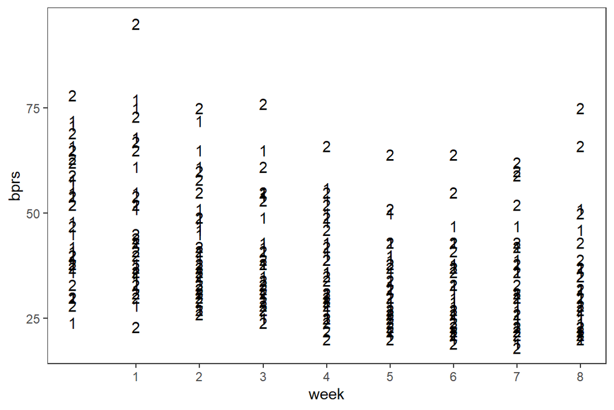

```r
p1 <- ggplot(BPRSL, aes(x = week, y = bprs, group = subject))
p2 <- p1 + geom_text(aes(label = treatment))
p3 <- p2 + scale_x_continuous(name = "week", breaks = seq(0:8))
p4 <- p3 + scale_y_continuous(name = "bprs")
p5 <- p4 + theme_bw()
p6 <- p5 + theme(panel.grid.major = element_blank(), panel.grid.minor = element_blank())
p6
```

Here, we have plotted bprs score on y-axis and week number in x-axis. Treatment group is used as a label for each observation. The labels are overlapping so it’s quite difficult to interpret what is happening in the plot, but it seems that group 2 is more represented in the high and low ends of the bprs scale throughout the trial compared to group 1.

Next we will fit a linear regression model to the data. We will do this, even though we know that this model is not appropriate fit to the data (due to the repeated measure nature of the data bprs measures are not independent of each other), to demonstrate how the model selection influences the results you receive.

#### **Fitting linear regression model to BPRS**:

```r
BPRS_reg <- lm(bprs ~ week + treatment, data = BPRSL)
summary(BPRS_reg)
```

```
##
## Call:
## lm(formula = bprs ~ week + treatment, data = BPRSL)
##
## Residuals:
##     Min      1Q  Median      3Q     Max
## -22.454  -8.965  -3.196   7.002  50.244
##
## Coefficients:
##             Estimate Std. Error t value Pr(>|t|)
## (Intercept)  46.4539     1.3670  33.982   <2e-16 ***
## week         -2.2704     0.2524  -8.995   <2e-16 ***
## treatment2    0.5722     1.3034   0.439    0.661
## ---
## Signif. codes:  0 '***' 0.001 '**' 0.01 '*' 0.05 '.' 0.1 ' ' 1
##
## Residual standard error: 12.37 on 357 degrees of freedom
## Multiple R-squared:  0.1851, Adjusted R-squared:  0.1806
## F-statistic: 40.55 on 2 and 357 DF,  p-value: < 2.2e-16
```

For now, we can say that when week and treatment are included to the model at the same time, only week have statistically significant effect (p<.05) on bprs, where bprs score decreases 2.2 units when week increases one unit.

We will get back to these results after we have calculated the more appropriate linear mixed effects model for the same data.

#### **Fitting linear mixed effects model to BPRS**:

Before running the LME, we will visualize once more the BPRS data set.

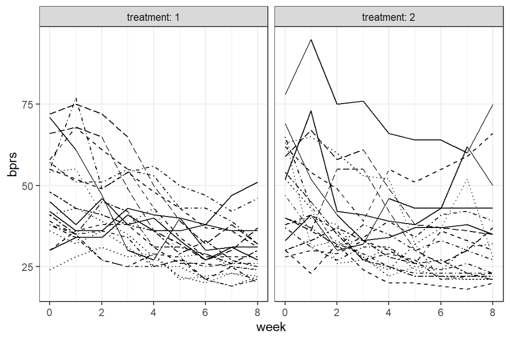

```r
p1 <- ggplot(BPRSL, aes(x = week, y = bprs, linetype = subject))
p2 <- p1 + geom_line() + scale_linetype_manual(values = rep(1:10, times=4))
p3 <- p2 + facet_grid(. ~ treatment, labeller = label_both)
p4 <- p3 + theme_bw() + theme(legend.position = "none")
p5 <- p4 + theme(panel.grid.minor.y = element_blank())
p6 <- p5 + scale_y_continuous(limits = c(min(BPRSL$bprs), max(BPRSL$bprs)))
p6
```

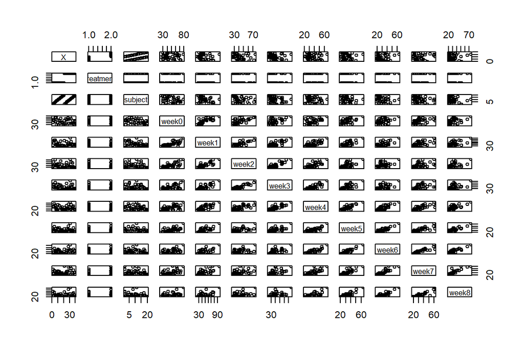

```r
pairs(BPRS, cex = 0.7)
```

**Did not have time for comments :(**

**Model1**

```r
library(lme4)
BPRS_ref <- lmer(bprs ~ week + treatment + (1 | subject), data = BPRSL, REML = FALSE)
summary(BPRS_ref)
```

```
## Linear mixed model fit by maximum likelihood  ['lmerMod']
## Formula: bprs ~ week + treatment + (1 | subject)
##    Data: BPRSL
##
##      AIC      BIC   logLik deviance df.resid
##   2748.7   2768.1  -1369.4   2738.7      355
##
## Scaled residuals:
##     Min      1Q  Median      3Q     Max
## -3.0481 -0.6749 -0.1361  0.4813  3.4855
##
## Random effects:
##  Groups   Name        Variance Std.Dev.
##  subject  (Intercept)  47.41    6.885
##  Residual             104.21   10.208
## Number of obs: 360, groups:  subject, 20
##
## Fixed effects:
##             Estimate Std. Error t value
## (Intercept)  46.4539     1.9090  24.334
## week         -2.2704     0.2084 -10.896
## treatment2    0.5722     1.0761   0.532
##
## Correlation of Fixed Effects:
##            (Intr) week
## week       -0.437
## treatment2 -0.282  0.000
```

**Model2**

```r
BPRS_ref1 <- lmer(bprs ~ week + treatment + (week | subject), data = BPRSL, REML = FALSE)
summary(BPRS_ref1)
```

```
## Linear mixed model fit by maximum likelihood  ['lmerMod']
## Formula: bprs ~ week + treatment + (week | subject)
##    Data: BPRSL
##
##      AIC      BIC   logLik deviance df.resid
##   2745.4   2772.6  -1365.7   2731.4      353
##
## Scaled residuals:
##     Min      1Q  Median      3Q     Max
## -2.8919 -0.6194 -0.0691  0.5531  3.7977
##
## Random effects:
##  Groups   Name        Variance Std.Dev. Corr
##  subject  (Intercept) 64.8222  8.0512
##           week         0.9609  0.9803   -0.51
##  Residual             97.4304  9.8707
## Number of obs: 360, groups:  subject, 20
##
## Fixed effects:
##             Estimate Std. Error t value
## (Intercept)  46.4539     2.1052  22.066
## week         -2.2704     0.2977  -7.626
## treatment2    0.5722     1.0405   0.550
##
## Correlation of Fixed Effects:
##            (Intr) week
## week       -0.582
## treatment2 -0.247  0.000
```

```r
anova(BPRS_ref1, BPRS_ref)
```

```
## Data: BPRSL
## Models:
## BPRS_ref: bprs ~ week + treatment + (1 | subject)
## BPRS_ref1: bprs ~ week + treatment + (week | subject)
##           Df    AIC    BIC  logLik deviance  Chisq Chi Df Pr(>Chisq)
## BPRS_ref   5 2748.7 2768.1 -1369.4   2738.7
## BPRS_ref1  7 2745.4 2772.6 -1365.7   2731.4 7.2721      2    0.02636 *
## ---
## Signif. codes:  0 '***' 0.001 '**' 0.01 '*' 0.05 '.' 0.1 ' ' 1
```

**Model3**

```r
BPRS_ref2 <- lmer(bprs ~ week * treatment + (week | subject), data = BPRSL, REML = FALSE)
summary(BPRS_ref2)
```

```
## Linear mixed model fit by maximum likelihood  ['lmerMod']
## Formula: bprs ~ week * treatment + (week | subject)
##    Data: BPRSL
##
##      AIC      BIC   logLik deviance df.resid
##   2744.3   2775.4  -1364.1   2728.3      352
##
## Scaled residuals:
##     Min      1Q  Median      3Q     Max
## -3.0512 -0.6271 -0.0768  0.5288  3.9260
##
## Random effects:
##  Groups   Name        Variance Std.Dev. Corr
##  subject  (Intercept) 64.9964  8.0620
##           week         0.9687  0.9842   -0.51
##  Residual             96.4707  9.8220
## Number of obs: 360, groups:  subject, 20
##
## Fixed effects:
##                 Estimate Std. Error t value
## (Intercept)      47.8856     2.2521  21.262
## week             -2.6283     0.3589  -7.323
## treatment2       -2.2911     1.9090  -1.200
## week:treatment2   0.7158     0.4010   1.785
##
## Correlation of Fixed Effects:
##             (Intr) week   trtmn2
## week        -0.650
## treatment2  -0.424  0.469
## wek:trtmnt2  0.356 -0.559 -0.840
```

```r
anova(BPRS_ref1, BPRS_ref2)
```

```
## Data: BPRSL
## Models:
## BPRS_ref1: bprs ~ week + treatment + (week | subject)
## BPRS_ref2: bprs ~ week * treatment + (week | subject)
##           Df    AIC    BIC  logLik deviance  Chisq Chi Df Pr(>Chisq)
## BPRS_ref1  7 2745.4 2772.6 -1365.7   2731.4
## BPRS_ref2  8 2744.3 2775.4 -1364.1   2728.3 3.1712      1    0.07495 .
## ---
## Signif. codes:  0 '***' 0.001 '**' 0.01 '*' 0.05 '.' 0.1 ' ' 1
```

**Quick interpretation**: model 1 is LME with random intercept only, 2 with random slope and intercept, 3 with random slope and intercept + interaction for week*treatment. AIC is best for model 3 but ANOVA did not indicate significant difference in fit with Model2 & 3. CIs or p-values for estimates were not provided, but the size of the t-value indicates that the treatment groups did not differ from each other in regard to bprs in the model 2.